# Effectiveness of the NFL Draft

## By Filip Piasevoli

fpiasevoli@gmail.com

January 19, 2015

## Question:

Can the strength of a team's draft class predict performance in the following years?

```python
%matplotlib inline

import numpy as np
import pandas as pd # pandas
import matplotlib.pyplot as plt # module for plotting
```

### Preprocessing

I chose to value my draft picks by position according to the Weibull distribution set forth by Massey in his [paper](http://www.nber.org/papers/w11270).

```python
# val(t)= e^ (-lambda*(t-1)^Beta)
# lambda=0.148, beta=0.700
#using Weibull parameters from the Massey paper
# Uses the no. 1 overall pick as numeraire

def draft_val(pick):
    lam=0.148
    beta=0.700
    return np.exp(-1.0*lam*(pick-1)**beta)
```

```python
#create dataframes for each draft since 2008
draft_dict={}
for year in range(2008,2015):
    draft_dict[str(year)]=pd.io.parsers.read_csv("C:/Users/Filip/Desktop/Harvard/NFL draft/"
                                                 +str(year)+"_draft.csv")
    draft_dict[str(year)]['Year']=year
    ## use the Weibull distribution function defined later in the code
    draft_dict[str(year)]['Pick_val']=draft_val(draft_dict[str(year)]['Player']).tolist()


draft_master=pd.concat(draft_dict)
cols=draft_master.columns.tolist()
draft_master=draft_master.reset_index()
draft_master=draft_master[cols]
draft_master.head()
```

|  | Round | Pick | Player | Name | Team | Position | College | Year | Pick_val |
| --- | --- | --- | --- | --- | --- | --- | --- | --- | --- |
| 0 | 1 | 1 | 1 | Jake Long | Dolphins | T | Michigan | 2008 | 1.000000 |
| 1 | 1 | 2 | 2 | Chris Long | Rams | DE | Virginia | 2008 | 0.862431 |
| 2 | 1 | 3 | 3 | Matt Ryan | Falcons | QB | Boston College | 2008 | 0.786292 |
| 3 | 1 | 4 | 4 | Darren McFadden | Raiders | RB | Arkansas | 2008 | 0.726632 |
| 4 | 1 | 5 | 5 | Glenn Dorsey | Chiefs | DT | Louisiana State | 2008 | 0.676668 |

```python
#Create one dataframe containing the record of every team going back to 2008
# Also cols for win differential compared to previous year

records=pd.io.parsers.read_csv("C:/Users/Filip/Desktop/Harvard/NFL draft/2008_record.csv")
records=records.sort('Team')
records=records[['Team','Wins']]
records.columns=['Team','2008']

for year in range(2009,2015):
    temp=pd.io.parsers.read_csv("C:/Users/Filip/Desktop/Harvard/NFL draft/"+str(year)+"_record.csv")
    wins=temp.sort('Team')['Wins'].tolist()
    records[str(year)]=wins

# one-year differentials
records['0809_diff']=records['2009']-records['2008']
records['0910_diff']=records['2010']-records['2009']
records['1011_diff']=records['2011']-records['2010']
records['1112_diff']=records['2012']-records['2011']
records['1213_diff']=records['2013']-records['2012']
records['1314_diff']=records['2014']-records['2013']

# two-year differentials
# the col name, 'X_2yr'=- (wins in yr x)-avg( wins in yr x+1, win in yr x+2)
records['08_2yr']=(records['2009']+records['2010'])*1.0/2-records['2008']
records['09_2yr']=(records['2010']+records['2011'])*1.0/2-records['2009']
records['10_2yr']=(records['2011']+records['2012'])*1.0/2-records['2010']
records['11_2yr']=(records['2012']+records['2013'])*1.0/2-records['2011']
records['12_2yr']=(records['2013']+records['2014'])*1.0/2-records['2012']

# three-year differentials
records['08_3yr']=(records['2009']+records['2010']+records['2011'])*1.0/3-records['2008']
records['09_3yr']=(records['2012']+records['2010']+records['2011'])*1.0/3-records['2009']
records['10_3yr']=(records['2012']+records['2013']+records['2011'])*1.0/3-records['2010']
records['11_3yr']=(records['2012']+records['2013']+records['2014'])*1.0/3-records['2011']

records.head()
```

|  | Team | 2008 | 2009 | 2010 | 2011 | 2012 | 2013 | 2014 | 0809_diff | 0910_diff | ... | 1314_diff | 08_2yr | 09_2yr | 10_2yr | 11_2yr | 12_2yr | 08_3yr | 09_3yr | 10_3yr | 11_3yr |
| --- | --- | --- | --- | --- | --- | --- | --- | --- | --- | --- | --- | --- | --- | --- | --- | --- | --- | --- | --- | --- | --- |
| 22 | 49ers | 7 | 8 | 6 | 13 | 11 | 12 | 8 | 1 | -2 | ... | -4 | 0 | 1.5 | 6.0 | -1.5 | -1.0 | 2.000000 | 2.000000 | 6.000000 | -2.666667 |
| 13 | Bears | 9 | 7 | 11 | 8 | 10 | 8 | 5 | -2 | 4 | ... | -3 | 0 | 2.5 | -2.0 | 1.0 | -3.5 | -0.333333 | 2.666667 | -2.333333 | -0.333333 |
| 26 | Bengals | 4 | 10 | 4 | 9 | 10 | 11 | 10 | 6 | -6 | ... | -1 | 3 | -3.5 | 5.5 | 1.5 | 0.5 | 3.666667 | -2.333333 | 6.000000 | 1.333333 |
| 21 | Bills | 7 | 6 | 4 | 6 | 6 | 6 | 9 | -1 | -2 | ... | 3 | -2 | -1.0 | 2.0 | 0.0 | 1.5 | -1.666667 | -0.666667 | 2.000000 | 1.000000 |
| 20 | Broncos | 8 | 8 | 4 | 8 | 13 | 13 | 12 | 0 | -4 | ... | -1 | -2 | -2.0 | 6.5 | 5.0 | -0.5 | -1.333333 | 0.333333 | 7.333333 | 4.666667 |

5 rows × 23 columns

```python
#create list of teams
team_list=records['Team'].tolist()

draft_team_year=draft_master.groupby(['Year','Team'])

draft_summary={}

#create a dictionary that holds the sum of a team's draft pick in a given year
for year in range(2008,2015):
    year_temp={}

    for team in team_list:
        team_temp=draft_team_year.get_group((year,team))
        year_temp[team]=sum(team_temp['Pick_val'])
    draft_summary[str(year)]=year_temp
```

# Draft picks vs Win Differential

Want to investigate how the number of draft picks affects wins in the coming year

# NOTE

The code from here until the heading 'January 17, 2015' has been outdated by changes made to the draft_summary dictionary. The code and plots remain to illustrate the timeline of the work. The main difference in this section is that each draft pick is valued equally.

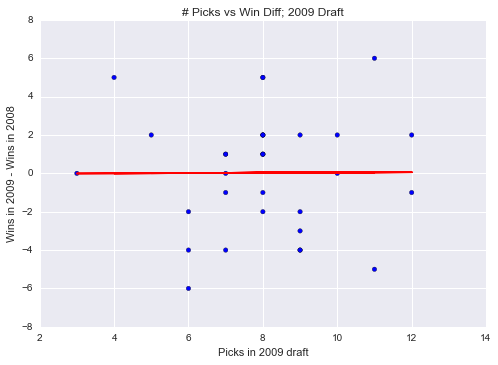

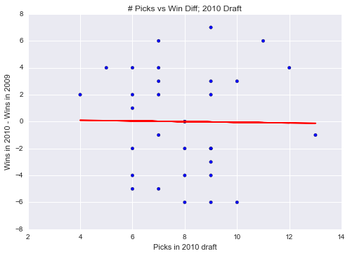

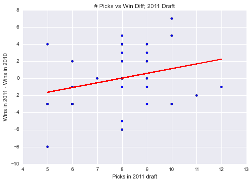

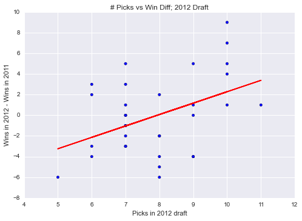

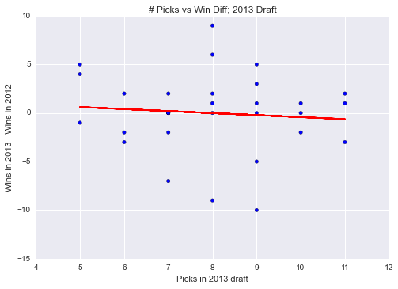

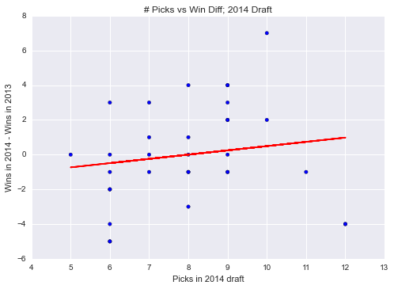

```python
## CODE IS OUTDATED

temp=[]

for team in team_list:
    temp.append(draft_summary['2009'][team])

p = np.polyfit(temp,records['0809_diff'],1)
plt.plot(temp,(p[0]*pd.Series(temp)+p[1]).tolist(),'r-') # A red solid line

plt.scatter(temp,records['0809_diff'])
plt.xlabel('Picks in 2009 draft')
plt.ylabel('Wins in 2009 - Wins in 2008')
plt.title('# Picks vs Win Diff; 2009 Draft')
plt.show()

temp=[]

for team in team_list:
    temp.append(draft_summary['2010'][team])

p = np.polyfit(temp,records['0910_diff'],1)
plt.plot(temp,(p[0]*pd.Series(temp)+p[1]).tolist(),'r-') # A red solid line

plt.scatter(temp,records['0910_diff'])
plt.xlabel('Picks in 2010 draft')
plt.ylabel('Wins in 2010 - Wins in 2009')
plt.title('# Picks vs Win Diff; 2010 Draft')
plt.show()

temp=[]

for team in team_list:
    temp.append(draft_summary['2011'][team])

p = np.polyfit(temp,records['1011_diff'],1)
plt.plot(temp,(p[0]*pd.Series(temp)+p[1]).tolist(),'r-') # A red solid line

plt.scatter(temp,records['1011_diff'])
plt.xlabel('Picks in 2011 draft')
plt.ylabel('Wins in 2011 - Wins in 2010')
plt.title('# Picks vs Win Diff; 2011 Draft')
plt.show()

temp=[]

for team in team_list:
    temp.append(draft_summary['2012'][team])

p = np.polyfit(temp,records['1112_diff'],1)
plt.plot(temp,(p[0]*pd.Series(temp)+p[1]).tolist(),'r-') # A red solid line

plt.scatter(temp,records['1112_diff'])
plt.xlabel('Picks in 2012 draft')
plt.ylabel('Wins in 2012 - Wins in 2011')
plt.title('# Picks vs Win Diff; 2012 Draft')
plt.show()

temp=[]

for team in team_list:
    temp.append(draft_summary['2013'][team])

p = np.polyfit(temp,records['1213_diff'],1)
plt.plot(temp,(p[0]*pd.Series(temp)+p[1]).tolist(),'r-') # A red solid line

plt.scatter(temp,records['1213_diff'])
plt.xlabel('Picks in 2013 draft')
plt.ylabel('Wins in 2013 - Wins in 2012')
plt.title('# Picks vs Win Diff; 2013 Draft')
plt.show()

temp=[]

for team in team_list:
    temp.append(draft_summary['2014'][team])

p = np.polyfit(temp,records['1314_diff'],1)
plt.plot(temp,(p[0]*pd.Series(temp)+p[1]).tolist(),'r-') # A red solid line

plt.scatter(temp,records['1314_diff'])
plt.xlabel('Picks in 2014 draft')
plt.ylabel('Wins in 2014 - Wins in 2013')
plt.title('# Picks vs Win Diff; 2014 Draft')
plt.show()

# https://medium.com/the-cauldron/the-2011-nfl-draft-class-might-be-the-best-ever-596113be87be
```

## Draft Pick Worth For Teams With 7 or less Wins

Want to investigate how the number of draft picks affects wins in the coming year for teams who have the ability to greatly improve their records so I only considered teams with 7 or less wins

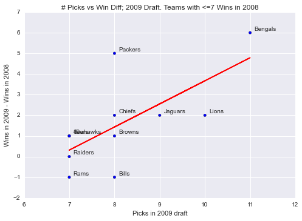

```
Each draft pick was approximately worth 1.11855670103 win
```

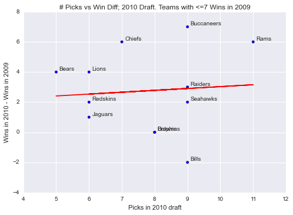

```
Each draft pick was approximately worth 0.124087591241 win
```

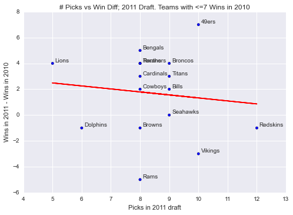

```
Each draft pick was approximately worth -0.232289950577 win
```

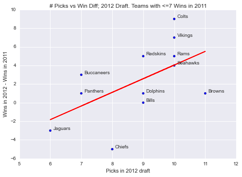

```
Each draft pick was approximately worth 1.46753246753 win
```

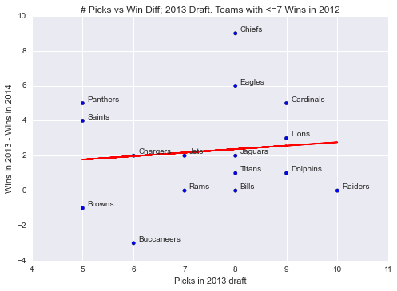

```
Each draft pick was approximately worth 0.198675496689 win
```

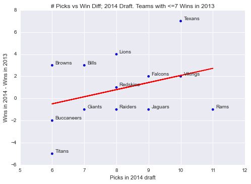

```
Each draft pick was approximately worth 0.642523364486 win
```

```python
## CODE IS OUTDATED

team_subset=records[records['2008']<=7]
team_subset_bool=records['2008']<=7
team_subset_list=team_subset['Team'].tolist()

temp=[]

for team in team_subset_list:
    temp.append(draft_summary['2009'][team])

p = np.polyfit(temp,records[team_subset_bool]['0809_diff'],1)
plt.plot(temp,(p[0]*pd.Series(temp)+p[1]).tolist(),'r-') # A red solid line

plt.scatter(temp,records[team_subset_bool]['0809_diff'])
plt.xlabel('Picks in 2009 draft')
plt.ylabel('Wins in 2009 - Wins in 2008')
plt.title('# Picks vs Win Diff; 2009 Draft. Teams with <=7 Wins in 2008')

for i, txt in enumerate(team_subset_list):
    plt.annotate(txt, (temp[i]+.1,records[team_subset_bool]['0809_diff'].tolist()[i]+.1))

plt.show()
print "Each draft pick was approximately worth "+str(p[0])+" win"

##############

team_subset=records[records['2009']<=7]
team_subset_bool=records['2009']<=7
team_subset_list=team_subset['Team'].tolist()

temp=[]

for team in team_subset_list:
    temp.append(draft_summary['2010'][team])

p = np.polyfit(temp,records[team_subset_bool]['0910_diff'],1)
plt.plot(temp,(p[0]*pd.Series(temp)+p[1]).tolist(),'r-') # A red solid line

plt.scatter(temp,records[team_subset_bool]['0910_diff'])
plt.xlabel('Picks in 2010 draft')
plt.ylabel('Wins in 2010 - Wins in 2009')
plt.title('# Picks vs Win Diff; 2010 Draft. Teams with <=7 Wins in 2009')

for i, txt in enumerate(team_subset_list):
    plt.annotate(txt, (temp[i]+.1,records[team_subset_bool]['0910_diff'].tolist()[i]+.1))

plt.show()
print "Each draft pick was approximately worth "+str(p[0])+" win"

###############

team_subset=records[records['2010']<=7]
team_subset_bool=records['2010']<=7
team_subset_list=team_subset['Team'].tolist()

temp=[]

for team in team_subset_list:
    temp.append(draft_summary['2011'][team])

p = np.polyfit(temp,records[team_subset_bool]['1011_diff'],1)
plt.plot(temp,(p[0]*pd.Series(temp)+p[1]).tolist(),'r-') # A red solid line

plt.scatter(temp,records[team_subset_bool]['1011_diff'])
plt.xlabel('Picks in 2011 draft')
plt.ylabel('Wins in 2011 - Wins in 2010')
plt.title('# Picks vs Win Diff; 2011 Draft. Teams with <=7 Wins in 2010')

for i, txt in enumerate(team_subset_list):
    plt.annotate(txt, (temp[i]+.1,records[team_subset_bool]['1011_diff'].tolist()[i]+.1))

plt.show()
print "Each draft pick was approximately worth "+str(p[0])+" win"

########

team_subset=records[records['2011']<=7]
team_subset_bool=records['2011']<=7
team_subset_list=team_subset['Team'].tolist()

temp=[]

for team in team_subset_list:
    temp.append(draft_summary['2012'][team])

p = np.polyfit(temp,records[team_subset_bool]['1112_diff'],1)
plt.plot(temp,(p[0]*pd.Series(temp)+p[1]).tolist(),'r-') # A red solid line

plt.scatter(temp,records[team_subset_bool]['1112_diff'])
plt.xlabel('Picks in 2012 draft')
plt.ylabel('Wins in 2012 - Wins in 2011')
plt.title('# Picks vs Win Diff; 2012 Draft. Teams with <=7 Wins in 2011')

for i, txt in enumerate(team_subset_list):
    plt.annotate(txt, (temp[i]+.1,records[team_subset_bool]['1112_diff'].tolist()[i]+.1))

plt.show()
print "Each draft pick was approximately worth "+str(p[0])+" win"

##########

team_subset=records[records['2012']<=7]
team_subset_bool=records['2012']<=7
team_subset_list=team_subset['Team'].tolist()

temp=[]

for team in team_subset_list:
    temp.append(draft_summary['2013'][team])

p = np.polyfit(temp,records[team_subset_bool]['1213_diff'],1)
plt.plot(temp,(p[0]*pd.Series(temp)+p[1]).tolist(),'r-') # A red solid line

plt.scatter(temp,records[team_subset_bool]['1213_diff'])
plt.xlabel('Picks in 2013 draft')
plt.ylabel('Wins in 2013 - Wins in 2014')
plt.title('# Picks vs Win Diff; 2013 Draft. Teams with <=7 Wins in 2012')

for i, txt in enumerate(team_subset_list):
    plt.annotate(txt, (temp[i]+.1,records[team_subset_bool]['1213_diff'].tolist()[i]+.1))

plt.show()
print "Each draft pick was approximately worth "+str(p[0])+" win"

##########

team_subset=records[records['2013']<=7]
team_subset_bool=records['2013']<=7
team_subset_list=team_subset['Team'].tolist()

temp=[]

for team in team_subset_list:
    temp.append(draft_summary['2014'][team])

p = np.polyfit(temp,records[team_subset_bool]['1314_diff'],1)
plt.plot(temp,(p[0]*pd.Series(temp)+p[1]).tolist(),'r-') # A red solid line

plt.scatter(temp,records[team_subset_bool]['1314_diff'])
plt.xlabel('Picks in 2014 draft')
plt.ylabel('Wins in 2014 - Wins in 2013')
plt.title('# Picks vs Win Diff; 2014 Draft. Teams with <=7 Wins in 2013')

for i, txt in enumerate(team_subset_list):
    plt.annotate(txt, (temp[i]+.1,records[team_subset_bool]['1314_diff'].tolist()[i]+.1))

plt.show()
print "Each draft pick was approximately worth "+str(p[0])+" win"
```

## Work as of Jan 17, 2015

Goals: * Combine data to run regression over multiple years to get a better idea of trend (still use <= 7 wins in year prior). * Assign weights to the draft picks so not all are treated as equal. Use Weibull distribution fit in Massey paper * Run multiple regression over the CAVOA values for the draft picks going back multiple years to take into account earlier draft classes (perhaps use 3)

Note: Decided to consider teams with 8 or less wins since it's a less arbitrary cutoff than the 7-win cutoff I used before (only .500-or-worse teams). These teams still stand to greatly benefit from a successful draft in ways that can be captured by a higher win differential.

```python
draft_master.head()
```

|  | Round | Pick | Player | Name | Team | Position | College | Year | Pick_val |
| --- | --- | --- | --- | --- | --- | --- | --- | --- | --- |
| 0 | 1 | 1 | 1 | Jake Long | Dolphins | T | Michigan | 2008 | 1.000000 |
| 1 | 1 | 2 | 2 | Chris Long | Rams | DE | Virginia | 2008 | 0.862431 |
| 2 | 1 | 3 | 3 | Matt Ryan | Falcons | QB | Boston College | 2008 | 0.786292 |
| 3 | 1 | 4 | 4 | Darren McFadden | Raiders | RB | Arkansas | 2008 | 0.726632 |
| 4 | 1 | 5 | 5 | Glenn Dorsey | Chiefs | DT | Louisiana State | 2008 | 0.676668 |

## One-year regression

[figure not shown]

```
Correlation: 0.381771091003
R-squared: 0.145749165926
```

```python
## Going to regress on draft pick values from most recent draft as a predictor for win
# differential in the following year

min_wins=8

team_subset=records[records['2008']<=min_wins]
team_subset_bool=records['2008']<=min_wins
team_subset_list=team_subset['Team'].tolist()

#build lists of draft pick values and win differentials
draft_log=[]
record_log=[]

for team in team_subset_list:
    draft_log.append(draft_summary['2009'][team])
    record_log.append(records[records['Team']==team]['0809_diff'].values[0])

#####

team_subset=records[records['2009']<=min_wins]
team_subset_bool=records['2009']<=min_wins
team_subset_list=team_subset['Team'].tolist()

for team in team_subset_list:
    draft_log.append(draft_summary['2010'][team])
    record_log.append(records[records['Team']==team]['0910_diff'].values[0])

####

team_subset=records[records['2010']<=min_wins]
team_subset_bool=records['2010']<=min_wins
team_subset_list=team_subset['Team'].tolist()

for team in team_subset_list:
    draft_log.append(draft_summary['2011'][team])
    record_log.append(records[records['Team']==team]['1011_diff'].values[0])

####

team_subset=records[records['2011']<=min_wins]
team_subset_bool=records['2011']<=min_wins
team_subset_list=team_subset['Team'].tolist()

for team in team_subset_list:
    draft_log.append(draft_summary['2012'][team])
    record_log.append(records[records['Team']==team]['1112_diff'].values[0])

####

team_subset=records[records['2012']<=min_wins]
team_subset_bool=records['2012']<=min_wins
team_subset_list=team_subset['Team'].tolist()

for team in team_subset_list:
    draft_log.append(draft_summary['2013'][team])
    record_log.append(records[records['Team']==team]['1213_diff'].values[0])

####
team_subset=records[records['2013']<=min_wins]
team_subset_bool=records['2013']<=min_wins
team_subset_list=team_subset['Team'].tolist()

for team in team_subset_list:
    draft_log.append(draft_summary['2014'][team])
    record_log.append(records[records['Team']==team]['1314_diff'].values[0])

p = np.polyfit(draft_log,record_log,1)
plt.plot(draft_log,[i*p[0]+p[1] for i in draft_log],'r-') # A red solid line

plt.scatter(draft_log,record_log)
plt.xlabel('Cumulative Pick Value')
plt.ylabel('Win differential')
plt.title('# Picks vs Win Diff; Teams with <=7 Wins in previous year across 2008-2014 seasons ')
plt.show()
correlation = np.corrcoef(draft_log,record_log)[0,1]
print "Correlation: " +str(correlation)
print "R-squared: "+str(correlation**2)
```

### Comments:

Regressing on win-differentials only one year removed from the draft has a low R-squared value. One possible reason for this could be that most of the players don't become starters in the same year that they're drafted.

```python
import statsmodels.api as sm
```

## Multiple Regression

Going to run a multiple regression using two successive years of cumlative draft values as predictors to predict our value of interest, win differential. The 2-year win differential for year x is found above by averaging the wins in years x+1 and x+2 and subtracting from that value the number of wins in year x. To see the code where the win differential was computed, see the preprocessing section above.

```python
team_subset=records[records['2008']<=min_wins]
team_subset_bool=records['2008']<=min_wins
team_subset_list=team_subset['Team'].tolist()

#build lists of draft pick values and win differentials
draft_log=[]
record_log=[]

for team in team_subset_list:
    team_pair=[]
    team_pair.append(draft_summary['2009'][team])
    team_pair.append(draft_summary['2010'][team])
    draft_log.append(team_pair)
    record_log.append(records[records['Team']==team]['08_2yr'].values[0])

team_subset=records[records['2009']<=min_wins]
team_subset_bool=records['2009']<=min_wins
team_subset_list=team_subset['Team'].tolist()

for team in team_subset_list:
    team_pair=[]
    team_pair.append(draft_summary['2010'][team])
    team_pair.append(draft_summary['2011'][team])
    draft_log.append(team_pair)
    record_log.append(records[records['Team']==team]['09_2yr'].values[0])

####

team_subset=records[records['2010']<=min_wins]
team_subset_bool=records['2010']<=min_wins
team_subset_list=team_subset['Team'].tolist()


for team in team_subset_list:
    team_pair=[]
    team_pair.append(draft_summary['2011'][team])
    team_pair.append(draft_summary['2012'][team])
    draft_log.append(team_pair)
    record_log.append(records[records['Team']==team]['10_2yr'].values[0])
####

team_subset=records[records['2011']<=min_wins]
team_subset_bool=records['2011']<=min_wins
team_subset_list=team_subset['Team'].tolist()

for team in team_subset_list:
    team_pair=[]
    team_pair.append(draft_summary['2012'][team])
    team_pair.append(draft_summary['2013'][team])
    draft_log.append(team_pair)
    record_log.append(records[records['Team']==team]['11_2yr'].values[0])####

team_subset=records[records['2012']<=min_wins]
team_subset_bool=records['2012']<=min_wins
team_subset_list=team_subset['Team'].tolist()

for team in team_subset_list:
    team_pair=[]
    team_pair.append(draft_summary['2013'][team])
    team_pair.append(draft_summary['2014'][team])
    draft_log.append(team_pair)
    record_log.append(records[records['Team']==team]['12_2yr'].values[0])####

draft_df=pd.DataFrame(draft_log)
draft_df.columns=['Sum Draft val yr x+1','Sum draft val x+2']

draft_with_const=sm.add_constant(draft_df)
# do mult regr with a const
mult_regr_const = sm.OLS(record_log, draft_with_const).fit()

mult_regr_const.summary()
```

OLS Regression Results

| Dep. Variable: | y | R-squared: | 0.414 |
| --- | --- | --- | --- |
| Model: | OLS | Adj. R-squared: | 0.401 |
| Method: | Least Squares | F-statistic: | 30.41 |
| Date: | Mon, 19 Jan 2015 | Prob (F-statistic): | 1.03e-10 |
| Time: | 17:47:10 | Log-Likelihood: | -192.68 |
| No. Observations: | 89 | AIC: | 391.4 |
| Df Residuals: | 86 | BIC: | 398.8 |
| Df Model: | 2 |  |  |

|  | coef | std err | t | P>\|t\| | [95.0% Conf. Int.] |
| --- | --- | --- | --- | --- | --- |
| const | 0.6345 | 0.809 | 0.784 | 0.435 | -0.973 2.243 |
| Sum Draft val yr x+1 | 4.7003 | 0.782 | 6.010 | 0.000 | 3.146 6.255 |
| Sum draft val x+2 | -3.9537 | 0.749 | -5.281 | 0.000 | -5.442 -2.465 |

| Omnibus: | 2.050 | Durbin-Watson: | 2.143 |
| --- | --- | --- | --- |
| Prob(Omnibus): | 0.359 | Jarque-Bera (JB): | 1.735 |
| Skew: | -0.204 | Prob(JB): | 0.420 |
| Kurtosis: | 2.451 | Cond. No. | 7.00 |

```python
mult_regr_no_const=sm.OLS(record_log, draft_df).fit()

mult_regr_no_const.summary()
```

OLS Regression Results

| Dep. Variable: | y | R-squared: | 0.550 |
| --- | --- | --- | --- |
| Model: | OLS | Adj. R-squared: | 0.540 |
| Method: | Least Squares | F-statistic: | 53.26 |
| Date: | Mon, 19 Jan 2015 | Prob (F-statistic): | 7.90e-16 |
| Time: | 17:47:30 | Log-Likelihood: | -193.00 |
| No. Observations: | 89 | AIC: | 390.0 |
| Df Residuals: | 87 | BIC: | 395.0 |
| Df Model: | 2 |  |  |

|  | coef | std err | t | P>\|t\| | [95.0% Conf. Int.] |
| --- | --- | --- | --- | --- | --- |
| Sum Draft val yr x+1 | 5.1392 | 0.545 | 9.424 | 0.000 | 4.055 6.223 |
| Sum draft val x+2 | -3.6007 | 0.597 | -6.031 | 0.000 | -4.787 -2.414 |

| Omnibus: | 1.464 | Durbin-Watson: | 2.116 |
| --- | --- | --- | --- |
| Prob(Omnibus): | 0.481 | Jarque-Bera (JB): | 1.411 |
| Skew: | -0.200 | Prob(JB): | 0.494 |
| Kurtosis: | 2.530 | Cond. No. | 3.73 |

## Model evaluation

After fitting two models, one with an intercept term and one without, I found the inclusion of the intercept to be statistically insignificant as indicated by a p-value greater than 0.05 and a t value whose absolute value is less than 2. The model without an intercept term was better at explaining variation in the data as indicated by a higher adjusted R-squared value.

Next, I will include a third yeard as a predictor to see if I can improve on my progress. I expect my adjusted R-squared to slightly suffer with the inclusion of an additional predictor, but hopefully the added information will improve the model since it will include the value of players who will have been in the league for 3 years and are more likely to have become a starter.

### 3-year regression

Just as above, we will now run a regression with 3 predictors; the cumulative draft values from 3 consecutive years. As explained above, I expect the model's adjusted R-squared to suffer with the inclusion of another predictor AND because we are now considering 3-year windows instead of 2, we have less data points. This second problem can be remedied by obtaining more datapoints. If I find this model to improve on the 2-year model, I will get more data to receive a more accurate model.

```python
team_subset=records[records['2008']<=min_wins]
team_subset_bool=records['2008']<=min_wins
team_subset_list=team_subset['Team'].tolist()

#build lists of draft pick values and win differentials
draft_log=[]
record_log=[]

for team in team_subset_list:
    team_trips=[]
    team_trips.append(draft_summary['2009'][team])
    team_trips.append(draft_summary['2010'][team])
    team_trips.append(draft_summary['2011'][team])

    draft_log.append(team_trips)
    record_log.append(records[records['Team']==team]['08_3yr'].values[0])


team_subset=records[records['2009']<=min_wins]
team_subset_bool=records['2009']<=min_wins
team_subset_list=team_subset['Team'].tolist()

for team in team_subset_list:
    team_trips=[]
    team_trips.append(draft_summary['2010'][team])
    team_trips.append(draft_summary['2011'][team])
    team_trips.append(draft_summary['2012'][team])

    draft_log.append(team_trips)
    record_log.append(records[records['Team']==team]['09_3yr'].values[0])

    ####

team_subset=records[records['2010']<=min_wins]
team_subset_bool=records['2010']<=min_wins
team_subset_list=team_subset['Team'].tolist()


for team in team_subset_list:
    team_trips=[]
    team_trips.append(draft_summary['2011'][team])
    team_trips.append(draft_summary['2012'][team])
    team_trips.append(draft_summary['2013'][team])

    draft_log.append(team_trips)
    record_log.append(records[records['Team']==team]['10_3yr'].values[0])
####

team_subset=records[records['2011']<=min_wins]
team_subset_bool=records['2011']<=min_wins
team_subset_list=team_subset['Team'].tolist()

for team in team_subset_list:
    team_pair=[]
    team_trips.append(draft_summary['2012'][team])
    team_trips.append(draft_summary['2013'][team])
    team_trips.append(draft_summary['2014'][team])

    draft_log.append(team_trips)
    record_log.append(records[records['Team']==team]['11_3yr'].values[0])



draft_df=pd.DataFrame(draft_log)
draft_df=draft_df[[0,1,2]]

draft_df.columns=['Sum Draft val yr x+1','Sum draft val yr x+2','Sum draft val yr x+3']
#draft_with_const=sm.add_constant(draft_df)

mult_regr_no_const = sm.OLS(record_log, draft_df).fit()

mult_regr_no_const.summary()
```

OLS Regression Results

| Dep. Variable: | y | R-squared: | 0.469 |
| --- | --- | --- | --- |
| Model: | OLS | Adj. R-squared: | 0.445 |
| Method: | Least Squares | F-statistic: | 20.00 |
| Date: | Mon, 19 Jan 2015 | Prob (F-statistic): | 2.11e-09 |
| Time: | 20:55:01 | Log-Likelihood: | -160.37 |
| No. Observations: | 71 | AIC: | 326.7 |
| Df Residuals: | 68 | BIC: | 333.5 |
| Df Model: | 3 |  |  |

|  | coef | std err | t | P>\|t\| | [95.0% Conf. Int.] |
| --- | --- | --- | --- | --- | --- |
| Sum Draft val yr x+1 | 5.2379 | 0.854 | 6.135 | 0.000 | 3.534 6.942 |
| Sum draft val yr x+2 | -0.6356 | 0.817 | -0.778 | 0.439 | -2.266 0.995 |
| Sum draft val yr x+3 | -2.6417 | 1.015 | -2.603 | 0.011 | -4.667 -0.617 |

| Omnibus: | 9.591 | Durbin-Watson: | 2.011 |
| --- | --- | --- | --- |
| Prob(Omnibus): | 0.008 | Jarque-Bera (JB): | 9.703 |
| Skew: | 0.717 | Prob(JB): | 0.00782 |
| Kurtosis: | 4.106 | Cond. No. | 5.61 |

As expected, our model performance had fewer observations and slightly suffered as a result. The inclusion of a third year as a predictor saw the significance of the sum of draft values from year x+2 change. It's p-value is now much higher than 0.05 and the 95% confidence interval for its coefficient encompasses zero.

## Conclusions

The structure of the annual draft looks to help bring parity to the league. The worst teams are given higher picks which have been found to have [significantly greater value](http://www.nber.org/papers/w11270) than picks later in the draft.

I sought to investigate whether one can predict how well a team will perform in coming years based solely upon the strength of their draft classes. I found that a model incorporating the value of 2 prior draft classes can account for 55% of the variation in win differentials for teams with .500-or-worse records. An additional year as a predictor did not yield an improved model, but further work can be done to verify this finding by inlcuding years prior to 2008.

While an adjusted R-squared of 54% is not near 1.00, it suggests that having a successful draft does account for improved results. One possible reason for unexplained variation is simply the variation amongst draft picks. There has been no shortage of #1 overall picks who [didn't pan out](https://usatthebiglead.files.wordpress.com/2012/03/uspw_60452201.jpg), and plenty of late-round [gems](http://media.masslive.com/patriots/photo/10631045-large.jpg). Variation amongst picks, trades, strength of schedule, and other factors aren't accounted for in the model. Nonetheless, the findings present a valid way of incorporating draft class value to explain improved performances for teams with .500-or-worse records.